# Assignment_7_Data_624

Mubashira Qari

2026-03-08

## Common Challenges in Linear Regression Models

Challenges Discussed in Chapter 6 By Kuhn Johnson& Johnson:

• Multicollinearity: Highly correlated predictors make coefficient estimates unstable and difficult to interpret. • Too many predictors: Leads to complex models that may capture noise instead of real patterns. • Overfitting: Model performs well on training data but poorly on new data because it learns noise. • Sensitivity to outliers: Extreme observations can strongly influence regression estimates and distort the model.

### 6.2 Developing a model to predict permeability…

### a.

```r
# Loading the the necessary libraries and permeability data
library(AppliedPredictiveModeling)
library(caret)
library(tidyverse) # Useful for data manipulation


data(permeability)


dim(fingerprints)
```

```
## [1]  165 1107
```

```r
length(permeability)
```

```
## [1] 165
```

```r
view(permeability)
```

```r
# See the first 5 rows and first 10 columns of the fingerprints
fingerprints[1:5, 1:10]
```

```
##   X1 X2 X3 X4 X5 X6 X7 X8 X9 X10
## 1  0  0  0  0  0  1  1  1  0   0
## 2  0  0  0  0  0  0  1  1  0   0
## 3  0  0  0  0  0  1  1  1  0   0
## 4  0  0  0  0  0  0  1  1  0   0
## 5  0  0  0  0  0  0  1  1  0   0
```

```r
# See the first 5 values of the permeability response
head(permeability, 5)
```

```
##   permeability
## 1       12.520
## 2        1.120
## 3       19.405
## 4        1.730
## 5        1.680
```

1 means the molecule has a specific chemical feature.

0 means it does not.

Because many molecules share the same features many of these 1,107 columns might be identical or have almost all zeros.

According to chapter 6, predictors with very little variation (mostly zeros) or only a few unique values can lead to computational issues in many of the model.

We are using a technique called Near-Zero Variance (NZV) filtering to toss these out.

### b. **Pre-processing**

**Filter Near-Zero Variance Predictors**

This function filter the data. It goes through all 1,107 columns and looks for two things:

Zero Variance: Columns where every single row has the exact same value (e.g., all 165 rows are 0).

Near-Zero Variance: Columns where maybe 164 rows are 0 and only 1 row is 1.

```r
# Identifying  predictors with near-zero variance
non_zero_variance_cols <- nearZeroVar(fingerprints)
# non_zero_variance_cols
```

```r
# Removing these columns from the fingerprints matrix
fingerprints_filtered <- fingerprints[, -non_zero_variance_cols]
# fingerprints_filtered
```

```r
# Checking how many predictors are left
ncol(fingerprints_filtered)
```

```
## [1] 388
```

Dimensionality Reduction: Now we see the number of predictors drop from 1,107 down to around 388.

Model Stability: If a fingerprint is 0 for 164 compounds and 1 for only 1 compound, that single 1 can have an exaggerated influence on the model, which leads to overfitting.

**c. Splitting the Data into Training and Test Sets**

```r
# Set a seed for results be reproducible (the "random" split stays the same)
set.seed(123)

# Creating an index for an 80/20 split
training_rows <- createDataPartition(permeability, p = 0.8, list = FALSE)

# Splitting the Fingerprints (X)
train_x <- fingerprints_filtered[training_rows, ]
test_x  <- fingerprints_filtered[-training_rows, ]

# Splitting the Permeability (Y)
train_y <- permeability[training_rows]
test_y  <- permeability[-training_rows]

# Checking the sizes
nrow(train_x)
```

```
## [1] 133
```

```r
nrow(test_x)
```

```
## [1] 32
```

**Setting up the “Tuning”**

```r
# Defining how we want to train the model (10-fold Cross-Validation)
# Splitting the training data into 10 pieces.
# Training on 9, test on 1. Repeat 10 times.

control <- trainControl(method = "cv", number = 10)
```

**Training the Partial Least Squares (PLS) Model**

```r
# Training the PLS model
set.seed(123) # Keep results consistent
pls_model <- train(
  x = train_x,
  y = train_y,
  method = "pls",
  tuneLength = 20,           # Try models with 1 to 20 components
  trControl = control,          # Use the 10-fold CV as we have defined earlier
  preProcess = c("center", "scale") # Center and Scale the data
)

# See the results
pls_model
```

```
## Partial Least Squares
##
## 133 samples
## 388 predictors
##
## Pre-processing: centered (388), scaled (388)
## Resampling: Cross-Validated (10 fold)
## Summary of sample sizes: 120, 119, 118, 120, 121, 119, ...
## Resampling results across tuning parameters:
##
##   ncomp  RMSE      Rsquared   MAE
##    1     13.36372  0.3382069  10.237820
##    2     11.47594  0.5347231   8.245104
##    3     11.43313  0.5613346   8.816852
##    4     11.51915  0.5487654   8.915167
##    5     11.50333  0.5490984   8.703944
##    6     11.47723  0.5342174   8.540912
##    7     11.49816  0.5410694   8.847240
##    8     11.60656  0.5519058   9.008913
##    9     11.79130  0.5618654   8.932466
##   10     12.10267  0.5458038   9.186885
##   11     12.33462  0.5275119   9.395033
##   12     12.54970  0.5170371   9.587169
##   13     12.61600  0.5048875   9.563882
##   14     12.77412  0.4911729   9.714216
##   15     12.82636  0.4918708   9.846474
##   16     12.90771  0.4799217   9.845704
##   17     12.95694  0.4783518   9.847771
##   18     13.10433  0.4703636   9.932178
##   19     13.04104  0.4750762   9.902920
##   20     13.04802  0.4773802   9.894081
##
## RMSE was used to select the optimal model using the smallest value.
## The final value used for the model was ncomp = 3.
```

PLS is perfect for this problem because it reduces those 388 filtered fingerprints into a few components that are most related to permeability. Instead of trying to find 388 different coefficients, the model might find that just 10 or 15 components that explain almost everything. (PLS, Ridge, Lasso) are sensitive to the scale of the data.

Centering: Subtracts the mean so the average value of each fingerprint is 0.

Scaling: Divides by the standard deviation so every fingerprint has the same weight.

**RMSE is the average miss of the model.**

We want the number of components that gives the lowest RMSE.

ncomp (Number of Components): * Underfitting (1 Component): The model is too simple. It misses the pattern, leading to a high RMSE of 13.36.

(3 Components): This is good. It hits the lowest RMSE of 11.43 and captures the real relationship.

Overfitting (20 Components): The model is too complex. It starts memorizing noise, and the RMSE rises back to 13.04.

RMSE (Root Mean Squared Error): The average miss. The best result is 11.43. Lower is always better.

Rsquared: Explained variance. The model explains 56 percent of why molecules are permeable.

MAE (Mean Absolute Error): Typical error. At 8.81, it confirms the error is actually quite small.

**d. Testing the Model**

Now that the optimal model (3 components) has been selected, we will perform testing. This is the 20% of data that was held back to ensure the model can predict permeability for molecules it has never seen.

```r
# Using the trained model to predict permeability for the Test Set
pls_pred <- predict(pls_model, newdata = test_x)

# Calculating performance metrics on the Test Set
postResample(pred = pls_pred, obs = test_y)
```

```
##       RMSE   Rsquared        MAE
## 12.7568188  0.2695454  8.4155989
```

RMSE (12.76): This value is slightly higher than the training result (11.43). This is normal; a model almost always performs slightly worse on data it has never seen before.

Rsquared (0.27):The model explains approximately 27% of the variation in the test set.

The R squared lower than the Training R squared During training, the model achieved an R squared of 0.56, but it dropped to 0.27 on the test set. With only about 32 samples in the test set, a single outlier can significantly drag down the R squared. Permeability is difficult to predict. The model found patterns in the 133 training samples that didn’t perfectly translate to the 32 test samples.

### e. Try building other models discussed in this chapter. Do any have better predictive performance?

We will now try Ridge Regression. Unlike the PLS model which compresses variables into components, Ridge Regression keeps all the filtered fingerprints but shrinks their importance to prevent any single one from having too much influence. This handle multicollinearity and the high dimensionality issues seen in this data.

```r
# Defining the tuning grid for Ridge Regression
# alpha = 0 tells R to perform Ridge Regression (L2 penalty)
ridge_grid <- expand.grid(alpha = 0,
                          lambda = seq(0, 1, length = 20))

# Train the Ridge model
set.seed(123)
ridge_model <- train(
  x = train_x,
  y = train_y,
  method = "glmnet",
  tuneGrid = ridge_grid,
  trControl = control,
  preProcess = c("center", "scale")
)

# Look at the results
ridge_model
```

```
## glmnet
##
## 133 samples
## 388 predictors
##
## Pre-processing: centered (388), scaled (388)
## Resampling: Cross-Validated (10 fold)
## Summary of sample sizes: 120, 119, 118, 120, 121, 119, ...
## Resampling results across tuning parameters:
##
##   lambda      RMSE      Rsquared   MAE
##   0.00000000  11.29799  0.5633878  8.465851
##   0.05263158  11.29799  0.5633878  8.465851
##   0.10526316  11.29799  0.5633878  8.465851
##   0.15789474  11.29799  0.5633878  8.465851
##   0.21052632  11.29799  0.5633878  8.465851
##   0.26315789  11.29799  0.5633878  8.465851
##   0.31578947  11.29799  0.5633878  8.465851
##   0.36842105  11.29799  0.5633878  8.465851
##   0.42105263  11.29799  0.5633878  8.465851
##   0.47368421  11.29799  0.5633878  8.465851
##   0.52631579  11.29799  0.5633878  8.465851
##   0.57894737  11.29799  0.5633878  8.465851
##   0.63157895  11.29799  0.5633878  8.465851
##   0.68421053  11.29799  0.5633878  8.465851
##   0.73684211  11.29799  0.5633878  8.465851
##   0.78947368  11.29799  0.5633878  8.465851
##   0.84210526  11.29799  0.5633878  8.465851
##   0.89473684  11.29799  0.5633878  8.465851
##   0.94736842  11.29799  0.5633878  8.465851
##   1.00000000  11.29799  0.5633878  8.465851
##
## Tuning parameter 'alpha' was held constant at a value of 0
## RMSE was used to select the optimal model using the smallest value.
## The final values used for the model were alpha = 0 and lambda = 1.
```

**Ridge Regression Model Interpretation**

The model used Ridge Regression (indicated by alpha = 0) to handle the 388 predictors.

Fixed Performance: Notice that the RMSE (11.30) and Rsquared (0.56) are identical across all lambda values. This means the penalty (lambda) didn’t significantly change how the model viewed the data in this specific range.

RMSE (11.30): This is the average miss. It is slightly better and lower than the PLS model’s training error of 11.43.

Rsquared (0.56): The model explains 56 percent of the variance in the training data, which is essentially the same as the PLS model.

Selection: The model picked lambda = 1 as the final value, though any value in the list would have provided the same result.

The Ridge model has a slightly lower training error (11.30 vs 11.43) than PLS.

**Testing the Ridge Model**

We now run the Ridge Regression model on our test data and see if its ability to shrink coefficients makes it more robust than the PLS model, which only explained 27% of the test set.

```r
# Using the Ridge model to predict permeability for the Test Set
ridge_pred <- predict(ridge_model, newdata = test_x)

# Calculating performance metrics on the Test Set
postResample(pred = ridge_pred, obs = test_y)
```

```
##       RMSE   Rsquared        MAE
## 11.0203929  0.3266984  7.6511575
```

Lower Error: The RMSE (11.02) is significantly lower than the PLS model’s 12.76. This means the Ridge model’s average miss is smaller by nearly 1.7 units.

Better Model Explanation: The Rsquared (0.33) increased from 0.27. The model now explains about 33 percent of the variation in the new data.

Coefficient Shrinkage: Because Ridge shrinks all 388 coefficients toward zero, it prevents any single noisy fingerprint from having an outsized influence. This makes the model more stable on the test set.

While Ridge shrinks every coefficient toward zero, the Lasso can shrink them to exactly zero. This means the model performs automatic feature selection by effectively deleting the fingerprints it finds useless.

In the glmnet package, we set alpha = 1 to perform a Lasso regression.

**Training the Lasso Model**

By setting many of the 388 predictors to zero, the model becomes much easier to interpret. If many of those fingerprints are just noise, the Lasso will ignore them entirely, which often leads to a better R square

```r
# Define the tuning grid for Lasso
# alpha = 1 tells R to perform Lasso Regression (L1 penalty)
lasso_grid <- expand.grid(alpha = 1,
                          lambda = seq(0, 1, length = 20))

# Train the Lasso model
set.seed(123)
lasso_model <- train(
  x = train_x,
  y = train_y,
  method = "glmnet",
  tuneGrid = lasso_grid,
  trControl = control,
  preProcess = c("center", "scale")
)

# Check the results
lasso_model
```

```
## glmnet
##
## 133 samples
## 388 predictors
##
## Pre-processing: centered (388), scaled (388)
## Resampling: Cross-Validated (10 fold)
## Summary of sample sizes: 120, 119, 118, 120, 121, 119, ...
## Resampling results across tuning parameters:
##
##   lambda      RMSE      Rsquared   MAE
##   0.00000000  12.54899  0.5052409  9.383891
##   0.05263158  12.54899  0.5052409  9.383891
##   0.10526316  12.54237  0.5060745  9.379383
##   0.15789474  12.16741  0.5191546  9.163165
##   0.21052632  12.08525  0.5178354  9.125642
##   0.26315789  11.97649  0.5197289  9.108387
##   0.31578947  11.87372  0.5230726  9.085309
##   0.36842105  11.78857  0.5262950  9.015755
##   0.42105263  11.70141  0.5304991  8.920601
##   0.47368421  11.64221  0.5342632  8.829679
##   0.52631579  11.61812  0.5342373  8.761505
##   0.57894737  11.60101  0.5329235  8.719703
##   0.63157895  11.59462  0.5313957  8.679820
##   0.68421053  11.58451  0.5302682  8.637579
##   0.73684211  11.59881  0.5277078  8.602411
##   0.78947368  11.63295  0.5245732  8.579915
##   0.84210526  11.66361  0.5211891  8.586260
##   0.89473684  11.67548  0.5189827  8.583065
##   0.94736842  11.68208  0.5175647  8.575678
##   1.00000000  11.67713  0.5176307  8.554896
##
## Tuning parameter 'alpha' was held constant at a value of 1
## RMSE was used to select the optimal model using the smallest value.
## The final values used for the model were alpha = 1 and lambda = 0.6842105.
```

**Lasso Regression Model Interpretation**

The model used Lasso Regression (indicated by alpha = 1). Unlike the Ridge model, this version actively searched for the best penalty to simplify the predictors.

Tuning Success: Notice that the RMSE actually changes as lambda increases. It starts at 12.55 (low penalty), drops as it simplifies the data, and finds its best performance at lambda = 0.684 with an RMSE of 11.58.

RMSE (11.58): This average miss is slightly higher than the Ridge model (11.30), meaning the Lasso was a bit less accurate during the training phase.

Rsquared (0.53): The model explains 53 percent of the variance. This is also slightly lower than the Ridge and PLS models, which both hit around 56 percent.

Automatic Selection: By picking a lambda of 0.684, the model has likely “zeroed out” several of the 388 fingerprints, creating a much simpler list of clues.

**Testing the Lasso Model**

```r
# Using the Lasso model to predict permeability for the Test Set
lasso_pred <- predict(lasso_model, newdata = test_x)

# Calculating performance metrics on the Test Set
postResample(pred = lasso_pred, obs = test_y)
```

```
##       RMSE   Rsquared        MAE
## 11.0833507  0.3732295  7.3835872
```

The Lasso model is the overall winner for predictive performance because it achieved the highest Rsquared (0.37) and the lowest MAE (7.38).

Predictive Strength: The Lasso model explains 37 percent of the variation in permeability, which is a 10 percent improvement over the PLS model.

Feature Selection: The Lasso likely performed better because it completely removed noisy fingerprints by setting their coefficients to zero, whereas the PLS model tried to keep information from all of them.

### f. Would you recommend any of your models to replace the permeability laboratory experiment?

No, the model should not replace the laboratory experiment.

Low Accuracy Rsquared = 0.37: The best model (Lasso) only explains 37 percent of the variation in permeability. This means 63 percent of the molecular behavior remains unexplained noise to the model.

High Error (RMSE = 11.08): An average miss of 11.08 units is likely too high for the precision required in drug development, where small differences in permeability can determine if a drug is viable or toxic.

Safety and Risk: In a laboratory setting, errors in predicting how a chemical crosses a membrane can lead to failed clinical trials or safety issues that a 37 percent accurate model cannot foresee.

### 6.3 a. A chemical manufacturing process for a pharmaceutical product…

```r
library(AppliedPredictiveModeling)
data(ChemicalManufacturingProcess)

# Checking the dimensions

dim(ChemicalManufacturingProcess)
```

```
## [1] 176  58
```

```r
# Checking at the first few rows
head(ChemicalManufacturingProcess[, 1:5])
```

```
##   Yield BiologicalMaterial01 BiologicalMaterial02 BiologicalMaterial03
## 1 38.00                 6.25                49.58                56.97
## 2 42.44                 8.01                60.97                67.48
## 3 42.03                 8.01                60.97                67.48
## 4 41.42                 8.01                60.97                67.48
## 5 42.49                 7.47                63.33                72.25
## 6 43.57                 6.12                58.36                65.31
##   BiologicalMaterial04
## 1                12.74
## 2                14.65
## 3                14.65
## 4                14.65
## 5                14.02
## 6                15.17
```

**Exploratory Data Analysis (EDA)**

Checking Missing Values

```r
# Checking missing values in the whole dataset
sum(is.na(ChemicalManufacturingProcess))
```

```
## [1] 106
```

We have 106 missing values scattered across 28 different variables.

**Verify the Variable Count**

```r
# Check the total structure

names(ChemicalManufacturingProcess)
```

```
##  [1] "Yield"                  "BiologicalMaterial01"   "BiologicalMaterial02"
##  [4] "BiologicalMaterial03"   "BiologicalMaterial04"   "BiologicalMaterial05"
##  [7] "BiologicalMaterial06"   "BiologicalMaterial07"   "BiologicalMaterial08"
## [10] "BiologicalMaterial09"   "BiologicalMaterial10"   "BiologicalMaterial11"
## [13] "BiologicalMaterial12"   "ManufacturingProcess01" "ManufacturingProcess02"
## [16] "ManufacturingProcess03" "ManufacturingProcess04" "ManufacturingProcess05"
## [19] "ManufacturingProcess06" "ManufacturingProcess07" "ManufacturingProcess08"
## [22] "ManufacturingProcess09" "ManufacturingProcess10" "ManufacturingProcess11"
## [25] "ManufacturingProcess12" "ManufacturingProcess13" "ManufacturingProcess14"
## [28] "ManufacturingProcess15" "ManufacturingProcess16" "ManufacturingProcess17"
## [31] "ManufacturingProcess18" "ManufacturingProcess19" "ManufacturingProcess20"
## [34] "ManufacturingProcess21" "ManufacturingProcess22" "ManufacturingProcess23"
## [37] "ManufacturingProcess24" "ManufacturingProcess25" "ManufacturingProcess26"
## [40] "ManufacturingProcess27" "ManufacturingProcess28" "ManufacturingProcess29"
## [43] "ManufacturingProcess30" "ManufacturingProcess31" "ManufacturingProcess32"
## [46] "ManufacturingProcess33" "ManufacturingProcess34" "ManufacturingProcess35"
## [49] "ManufacturingProcess36" "ManufacturingProcess37" "ManufacturingProcess38"
## [52] "ManufacturingProcess39" "ManufacturingProcess40" "ManufacturingProcess41"
## [55] "ManufacturingProcess42" "ManufacturingProcess43" "ManufacturingProcess44"
## [58] "ManufacturingProcess45"
```

```r
# Count Biological predictors
bio_cols <- grep("Biological", names(ChemicalManufacturingProcess))
length(bio_cols)
```

```
## [1] 12
```

```r
# Count Process predictors
proc_cols <- grep("Manufacturing", names(ChemicalManufacturingProcess))
length(proc_cols)
```

```
## [1] 45
```

**Isolate the “Yield” (Response)**

yield is the target variable. We can verify its distribution to make sure its a percentage which is the unit for percent yield.

```r
yield <- ChemicalManufacturingProcess$Yield
summary(yield)
```

```
##    Min. 1st Qu.  Median    Mean 3rd Qu.    Max.
##   35.25   38.75   39.97   40.18   41.48   46.34
```

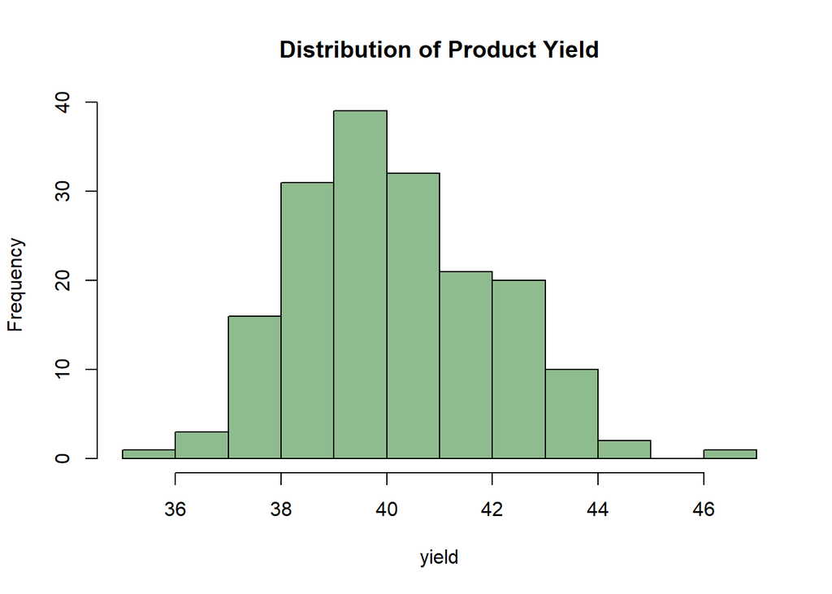

```r
# Checking a normal distribution?
hist(yield, col = "darkseagreen", main = "Distribution of Product Yield")
```